# Bellabeat Case Study

Ashwin Jain

8/18/2023

### Installing Packages

For this, I’ve installed the following packages

```r
library(readxl)
library(Rcpp)
library(magrittr)
library(dplyr)
```

```r
library(ggplot2)
library(janitor)
```

# Importing Data

We first need to load in our data. It was downloaded as csv files which I then exported to Excel for visual purposes

```r
daily_activity = read_excel("/Users/ashwinjain/Development/Personal/bellabeat-case-study/data/dailyActivity_merged.xlsx")
daily_sleep = read_excel("/Users/ashwinjain/Development/Personal/bellabeat-case-study/data/sleepDay_merged.xlsx")
```

# Cleaning Data

## daily_activity

We will first work with the daily_activity dataset

Preview of dailyActivities_merged

| Id | ActivityDate | TotalSteps | TotalDistance | TrackerDistance | LoggedActivitiesDistance | VeryActiveDistance | ModeratelyActiveDistance | LightActiveDistance | SedentaryActiveDistance | VeryActiveMinutes | FairlyActiveMinutes | LightlyActiveMinutes | SedentaryMinutes | Calories |
| --- | --- | --- | --- | --- | --- | --- | --- | --- | --- | --- | --- | --- | --- | --- |
| 1503960366 | 2016-04-12 | 13162 | 8.50 | 8.50 | 0 | 1.88 | 0.55 | 6.06 | 0 | 25 | 13 | 328 | 728 | 1985 |
| 1503960366 | 2016-04-13 | 10735 | 6.97 | 6.97 | 0 | 1.57 | 0.69 | 4.71 | 0 | 21 | 19 | 217 | 776 | 1797 |
| 1503960366 | 2016-04-14 | 10460 | 6.74 | 6.74 | 0 | 2.44 | 0.40 | 3.91 | 0 | 30 | 11 | 181 | 1218 | 1776 |
| 1503960366 | 2016-04-15 | 9762 | 6.28 | 6.28 | 0 | 2.14 | 1.26 | 2.83 | 0 | 29 | 34 | 209 | 726 | 1745 |
| 1503960366 | 2016-04-16 | 12669 | 8.16 | 8.16 | 0 | 2.71 | 0.41 | 5.04 | 0 | 36 | 10 | 221 | 773 | 1863 |

First, check the sample size

```r
n_distinct(daily_activity$Id)
```

```
## [1] 33
```

```r
n_distinct(daily_sleep$Id)
```

```
## [1] 24
```

Second, I deleted the SedentaryActiveDistance column - many of these entries had values over 0, which doesn’t make sense because being sedentary and on the move are mutually exclusive

Second, I decided we should check for duplicated data and remove extras

```r
sum(duplicated(daily_activity) == TRUE)
```

```
## [1] 0
```

```r
sum(duplicated(daily_sleep) == TRUE)
```

```
## [1] 3
```

The duplicated function outputs a list where the value of each indice in the list corresponds to whether that row is unique or not. The sum of all the TRUE values is 0, therefore, there are no duplicates

For the daily_sleep dataset however, there are 3 duplicates. We must reomve these duplicates as follows

```r
daily_sleep <- unique(daily_sleep)
sum(duplicated(daily_sleep) == TRUE)
```

```
## [1] 0
```

Third, we should remove irrelevant data. There are few things to consider here. First, the SedentaryActiveDistance column - this does not matter as sedentary distance will always be zero.

A few of the data points have sedentary distances greater than zero, which is an error.

```r
sum(daily_activity$SedentaryActiveDistance > 0)
```

```
## [1] 82
```

As we can see, there are 82 days amoungst these individuals where the technology logged distance traveled while the person was moving, so it should be removed

```r
daily_activity <- select(daily_activity, -SedentaryActiveDistance)
```

List of columns before - 15 total

```
##  [1] "Id"                       "ActivityDate"
##  [3] "TotalSteps"               "TotalDistance"
##  [5] "TrackerDistance"          "LoggedActivitiesDistance"
##  [7] "VeryActiveDistance"       "ModeratelyActiveDistance"
##  [9] "LightActiveDistance"      "SedentaryActiveDistance"
## [11] "VeryActiveMinutes"        "FairlyActiveMinutes"
## [13] "LightlyActiveMinutes"     "SedentaryMinutes"
## [15] "Calories"
```

List of columns after - 14 total

```
##  [1] "Id"                       "ActivityDate"
##  [3] "TotalSteps"               "TotalDistance"
##  [5] "TrackerDistance"          "LoggedActivitiesDistance"
##  [7] "VeryActiveDistance"       "ModeratelyActiveDistance"
##  [9] "LightActiveDistance"      "VeryActiveMinutes"
## [11] "FairlyActiveMinutes"      "LightlyActiveMinutes"
## [13] "SedentaryMinutes"         "Calories"
```

I am checking for calories burned to be less than 1000. Barring medical conditions, it is impossible to have a metabolic rate less than 1000 calories

```r
not_worn = subset(daily_activity, Calories < 1000)
# daily_activity <- subset(daily_activity, Calories > 1000)
# daily_activity
```

Rename columns

We can then rename the columns for a more standardized format

```r
clean_names(daily_activity)
```

```
## # A tibble: 940 × 14
##            id activity_date       total_steps total_distance tracker_distance
##         <dbl> <dttm>                    <dbl>          <dbl>            <dbl>
##  1 1503960366 2016-04-12 00:00:00       13162           8.5              8.5
##  2 1503960366 2016-04-13 00:00:00       10735           6.97             6.97
##  3 1503960366 2016-04-14 00:00:00       10460           6.74             6.74
##  4 1503960366 2016-04-15 00:00:00        9762           6.28             6.28
##  5 1503960366 2016-04-16 00:00:00       12669           8.16             8.16
##  6 1503960366 2016-04-17 00:00:00        9705           6.48             6.48
##  7 1503960366 2016-04-18 00:00:00       13019           8.59             8.59
##  8 1503960366 2016-04-19 00:00:00       15506           9.88             9.88
##  9 1503960366 2016-04-20 00:00:00       10544           6.68             6.68
## 10 1503960366 2016-04-21 00:00:00        9819           6.34             6.34
## # ℹ 930 more rows
## # ℹ 9 more variables: logged_activities_distance <dbl>,
## #   very_active_distance <dbl>, moderately_active_distance <dbl>,
## #   light_active_distance <dbl>, very_active_minutes <dbl>,
## #   fairly_active_minutes <dbl>, lightly_active_minutes <dbl>,
## #   sedentary_minutes <dbl>, calories <dbl>
```

```r
clean_names(daily_sleep)
```

```
## # A tibble: 410 × 5
##            id sleep_day           total_sleep_records total_minutes_asleep
##         <dbl> <dttm>                            <dbl>                <dbl>
##  1 1503960366 2016-04-12 00:00:00                   1                  327
##  2 1503960366 2016-04-13 00:00:00                   2                  384
##  3 1503960366 2016-04-15 00:00:00                   1                  412
##  4 1503960366 2016-04-16 00:00:00                   2                  340
##  5 1503960366 2016-04-17 00:00:00                   1                  700
##  6 1503960366 2016-04-19 00:00:00                   1                  304
##  7 1503960366 2016-04-20 00:00:00                   1                  360
##  8 1503960366 2016-04-21 00:00:00                   1                  325
##  9 1503960366 2016-04-23 00:00:00                   1                  361
## 10 1503960366 2016-04-24 00:00:00                   1                  430
## # ℹ 400 more rows
## # ℹ 1 more variable: total_time_in_bed <dbl>
```

```r
names(daily_activity) <- tolower(names(daily_activity))
names(daily_sleep) <- tolower(names(daily_sleep))
colnames(daily_activity)[2] = "date"
colnames(daily_sleep)[2] = "date"
glimpse(daily_activity)
```

```
## Rows: 940
## Columns: 14
## $ id                       <dbl> 1503960366, 1503960366, 1503960366, 150396036…
## $ date                     <dttm> 2016-04-12, 2016-04-13, 2016-04-14, 2016-04-…
## $ totalsteps               <dbl> 13162, 10735, 10460, 9762, 12669, 9705, 13019…
## $ totaldistance            <dbl> 8.50, 6.97, 6.74, 6.28, 8.16, 6.48, 8.59, 9.8…
## $ trackerdistance          <dbl> 8.50, 6.97, 6.74, 6.28, 8.16, 6.48, 8.59, 9.8…
## $ loggedactivitiesdistance <dbl> 0, 0, 0, 0, 0, 0, 0, 0, 0, 0, 0, 0, 0, 0, 0, …
## $ veryactivedistance       <dbl> 1.88, 1.57, 2.44, 2.14, 2.71, 3.19, 3.25, 3.5…
## $ moderatelyactivedistance <dbl> 0.55, 0.69, 0.40, 1.26, 0.41, 0.78, 0.64, 1.3…
## $ lightactivedistance      <dbl> 6.06, 4.71, 3.91, 2.83, 5.04, 2.51, 4.71, 5.0…
## $ veryactiveminutes        <dbl> 25, 21, 30, 29, 36, 38, 42, 50, 28, 19, 66, 4…
## $ fairlyactiveminutes      <dbl> 13, 19, 11, 34, 10, 20, 16, 31, 12, 8, 27, 21…
## $ lightlyactiveminutes     <dbl> 328, 217, 181, 209, 221, 164, 233, 264, 205, …
## $ sedentaryminutes         <dbl> 728, 776, 1218, 726, 773, 539, 1149, 775, 818…
## $ calories                 <dbl> 1985, 1797, 1776, 1745, 1863, 1728, 1921, 203…
```

```r
glimpse(daily_sleep)
```

```
## Rows: 410
## Columns: 5
## $ id                 <dbl> 1503960366, 1503960366, 1503960366, 1503960366, 150…
## $ date               <dttm> 2016-04-12, 2016-04-13, 2016-04-15, 2016-04-16, 20…
## $ totalsleeprecords  <dbl> 1, 2, 1, 2, 1, 1, 1, 1, 1, 1, 1, 1, 1, 1, 1, 1, 1, …
## $ totalminutesasleep <dbl> 327, 384, 412, 340, 700, 304, 360, 325, 361, 430, 2…
## $ totaltimeinbed     <dbl> 346, 407, 442, 367, 712, 320, 377, 364, 384, 449, 3…
```

Typically, we would like to rename the date column to provide a consistent format. However, the date column is already formatted properly, so this step is redundant

We next want to merge the daily_activity and daily_sleep columns by id and date. We must make sure both tables have the same column names for this.

Merge daily sleep and daily activity

```r
daily_activity_sleep <- merge(daily_activity, daily_sleep, by=c ("id", "date"))
```

# Processing Data

We will source every variable from the daily_activity table, with the exception of totalminutesasleep, which we will obtain from the daily_sleep table

```r
daily_activity_grouped <- daily_activity %>% group_by(id) %>% transmute(totalsteps=sum(totalsteps), totaldistance=sum(totaldistance), veryactivedistance = sum(veryactivedistance), moderatelyactivedistance = sum(moderatelyactivedistance), lightactivedistance=sum(lightactivedistance), veryactiveminutes=sum(veryactiveminutes), fairlyactiveminutes=sum(fairlyactiveminutes), lightlyactiveminutes=sum(lightlyactiveminutes), sedentaryminutes=sum(sedentaryminutes), calories=sum(calories))

daily_sleep_grouped <- daily_sleep %>% group_by(id) %>% transmute(totalminutesasleep=sum(totalminutesasleep))
```

We then need to get the total count of each id from both tables to determine the average

```r
activityCount <- table(daily_activity_grouped$id)
sleepCount <- table(daily_sleep_grouped$id)
```

Now we can get rid of duplicates and divide each row by its respective count

```r
daily_activity_grouped <- unique(daily_activity_grouped)
daily_sleep_grouped <- unique(daily_sleep_grouped)

daily_activity_average <- daily_activity_grouped
daily_sleep_average <- daily_sleep_grouped
```

```r
# obtain the average

for (i in 1:nrow(daily_activity_grouped)) {
  daily_activity_average[i, 2:ncol(daily_activity_grouped)] <- daily_activity_grouped[i, 2:ncol(daily_activity_grouped)] / activityCount[i]
}

for (i in 1:nrow(daily_sleep_grouped)) {
  daily_sleep_average[i, 2:ncol(daily_sleep_grouped)] <- daily_sleep_grouped[i, 2:ncol(daily_sleep_grouped)] / sleepCount[i]
}
```

```r
colnames(daily_activity_average)[2] = "averagesteps"
colnames(daily_activity_average)[3] = "averagedistance"
colnames(daily_sleep_average)[2] = "averagesleep"
```

```r
daily_activity_sleep_average <- merge(daily_activity_average, daily_sleep_average, by=c ("id"))
head(daily_activity_sleep_average)
```

```
##           id averagesteps averagedistance veryactivedistance
## 1 1503960366    12116.742       7.8096774        2.858387113
## 2 1644430081     7282.967       5.2953334        0.730000001
## 3 1844505072     2580.065       1.7061290        0.008387097
## 4 1927972279      916.129       0.6345161        0.095806451
## 5 2026352035     5566.871       3.4548387        0.006129032
## 6 2320127002     4716.871       3.1877419        0.106774193
##   moderatelyactivedistance lightactivedistance veryactiveminutes
## 1               0.79419354           4.1529032       38.70967742
## 2               0.95100000           3.6090000        9.56666667
## 3               0.04903226           1.6474193        0.12903226
## 4               0.03129032           0.5070968        1.32258065
## 5               0.01129032           3.4361290        0.09677419
## 6               0.09774193           2.9803226        1.35483871
##   fairlyactiveminutes lightlyactiveminutes sedentaryminutes calories
## 1          19.1612903            219.93548         848.1613 1816.419
## 2          21.3666667            178.46667        1161.8667 2811.300
## 3           1.2903226            115.45161        1206.6129 1573.484
## 4           0.7741935             38.58065        1317.4194 2172.806
## 5           0.2580645            256.64516         689.4194 1540.645
## 6           2.5806452            198.19355        1220.0968 1724.161
##   averagesleep
## 1     360.2800
## 2     294.0000
## 3     652.0000
## 4     417.0000
## 5     506.1786
## 6      61.0000
```

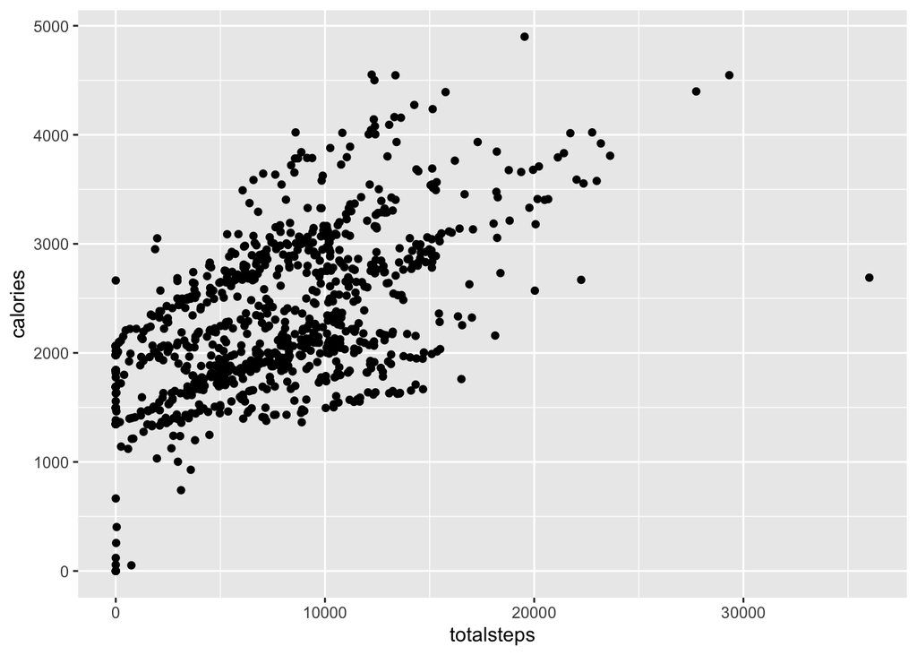

```r
ggplot(daily_activity, aes(totalsteps, calories)) + geom_point()
```

```r
res <- cor.test(daily_activity$totalsteps, daily_activity$calories, method = "pearson")
```

Let’s first examine when throughout the week people are taking their steps

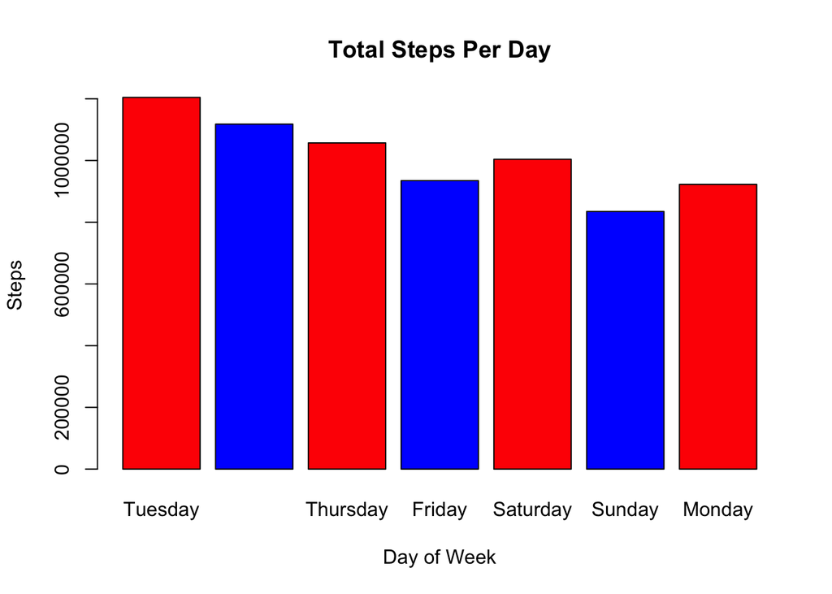

```r
hourly_steps = read_excel("/Users/ashwinjain/Development/Personal/bellabeat-case-study/data/hourlySteps_merged.xlsx")
hourly_steps$Weekday = weekdays(hourly_steps$ActivityHour)

weekdays = unique(hourly_steps$Weekday)

steps_per_day = c()

for(day in weekdays) {
  steps_per_day = append(steps_per_day, sum(subset(hourly_steps, Weekday == day)$StepTotal))
}

steps_per_day = data.frame(weekdays, steps_per_day)

barplot(steps_per_day$steps_per_day, xlab="Day of Week", ylab="Steps", main="Total Steps Per Day", names.arg = weekdays, col=c("red", "blue"))
```

As we can see here, Sunday and Monday are the worst days for taking steps. Furthermore, there are less steps being taken as the week goes on. This could be a sign that people are consistent towardsd the beginning of the week.. maybe due to a small burst in motivation, yet they start to fall

Lets take a look at when throughout the day people are taking their steps

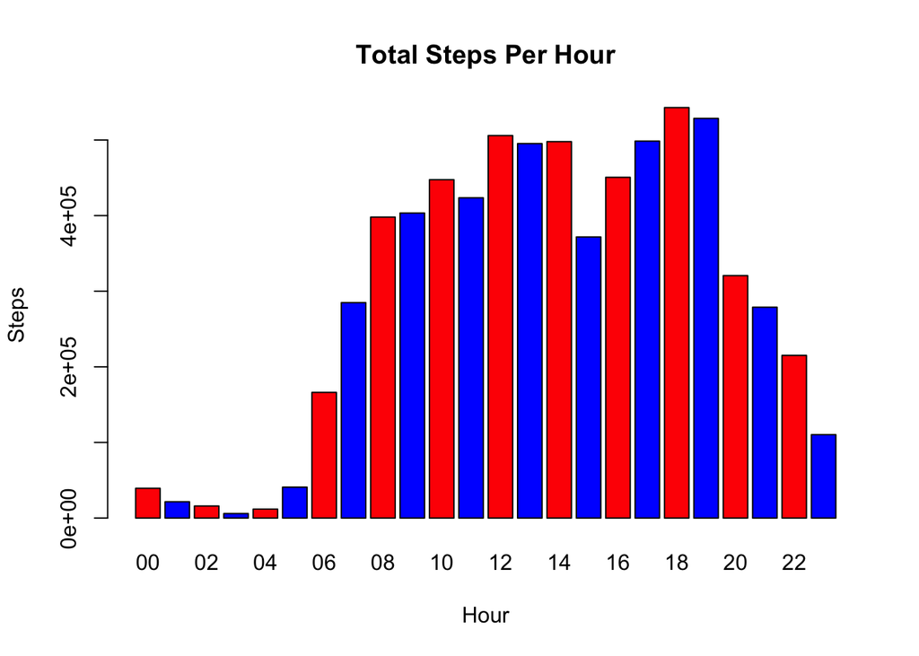

```r
hourly_steps$Hour = format(as.POSIXct(hourly_steps$ActivityHour), format = "%H")

hours = hourly_steps$Hour[1:24]

steps_per_hour = c()

for(hour in hours) {
  steps_per_hour = append(steps_per_hour, sum(subset(hourly_steps, Hour == hour)$StepTotal))
}

steps_per_hour = data.frame(hours, steps_per_hour)

barplot(steps_per_hour$steps_per_hour, xlab="Hour", ylab="Steps", main="Total Steps Per Hour", names.arg = hours, col=c("red", "blue"))
```

As expected, the step counts conform to the typical waking hours

Given this merged averaged dataset, we can extract a lot of information from this, the first of which should be classifying users based on activity level.

```r
daily_activity_sleep_average$usertype = with(daily_activity_sleep_average, ifelse(averagesteps >= 10000, "very active", ifelse(averagesteps >= 7500, "fairly active", ifelse(averagesteps >= 5000, "lightly active", "sedentary"))))
```